# Lab 5: Count Regression

Poisson, Negative Binomial, and Probing Interactions

Author

Marjan Nikbakhtzadeh

## 1. Purpose

This report examines the factors associated with physician office visits among older adults using the NMES1988 dataset. The analysis compares Gaussian, Poisson, negative binomial, zero-inflated, and hurdle models. It also investigates whether the association between chronic conditions and physician visits differs according to private insurance status.

## 2. Load packages and prepare the data

The reference categories were average health, male gender, and no private insurance. These categories serve as reference groups when interpreting regression coefficients.

```
[1] 4406    6
```

```
'data.frame':   4406 obs. of  6 variables:
 $ visits   : int  5 1 13 16 3 17 9 3 1 0 ...
 $ chronic  : int  2 2 4 2 2 5 0 0 0 0 ...
 $ health   : Factor w/ 3 levels "average","poor",..: 1 1 2 2 1 2 1 1 1 1 ...
 $ gender   : Factor w/ 2 levels "male","female": 1 2 2 1 2 2 2 2 2 2 ...
 $ school   : int  6 10 10 3 6 7 8 8 8 8 ...
 $ insurance: Factor w/ 2 levels "no","yes": 2 2 1 2 2 1 2 2 2 2 ...
```

```
[1] "average"   "poor"      "excellent"
```

```
[1] "male"   "female"
```

```
[1] "no"  "yes"
```

```
   visits   chronic    health    gender    school insurance
        0         0         0         0         0         0
```

## 3. Explore the data

### 3.1. Descriptive statistics

Descriptive Statistics for Physician Visits

| Sample size | Mean | Variance | Proportion of zeros | Maximum visits |
| --- | --- | --- | --- | --- |
| 4,406 | 5.77 | 45.69 | 15.5% | 89 |

### 3.2. Distribution of physician visits

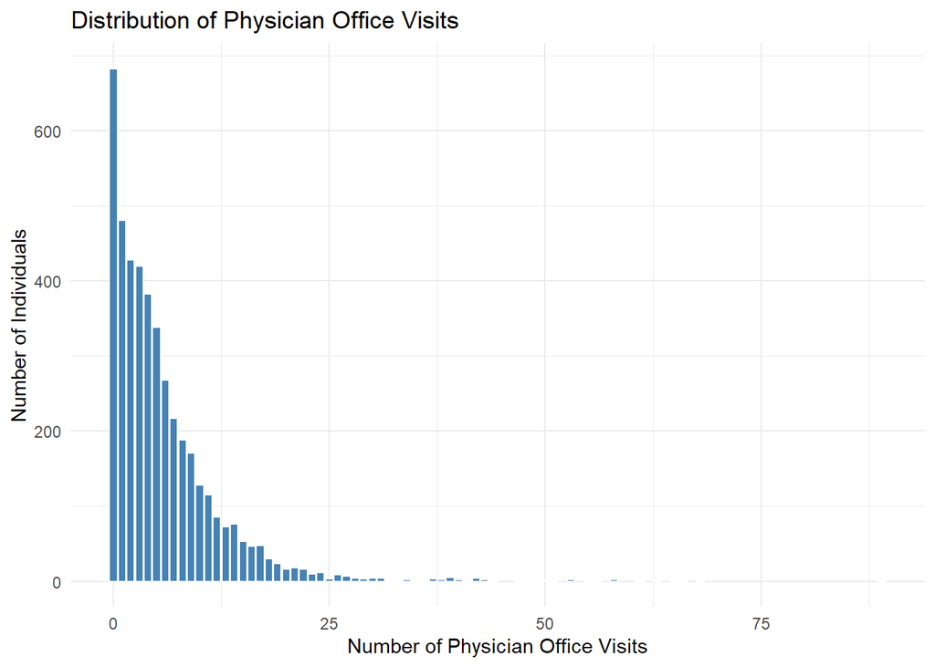

The outcome variable, visits, represents the number of physician office visits and is therefore a count variable. The mean was 5.77, whereas the variance was 45.69. Approximately 15.5% of individuals reported no physician visits. The maximum number of visits was 89. A variance substantially larger than the mean suggests overdispersion, indicating that a Poisson model may not adequately describe the data.

## 4. Gaussian model

A Gaussian model was fitted to demonstrate why a conventional linear model is not ideal for count outcomes.

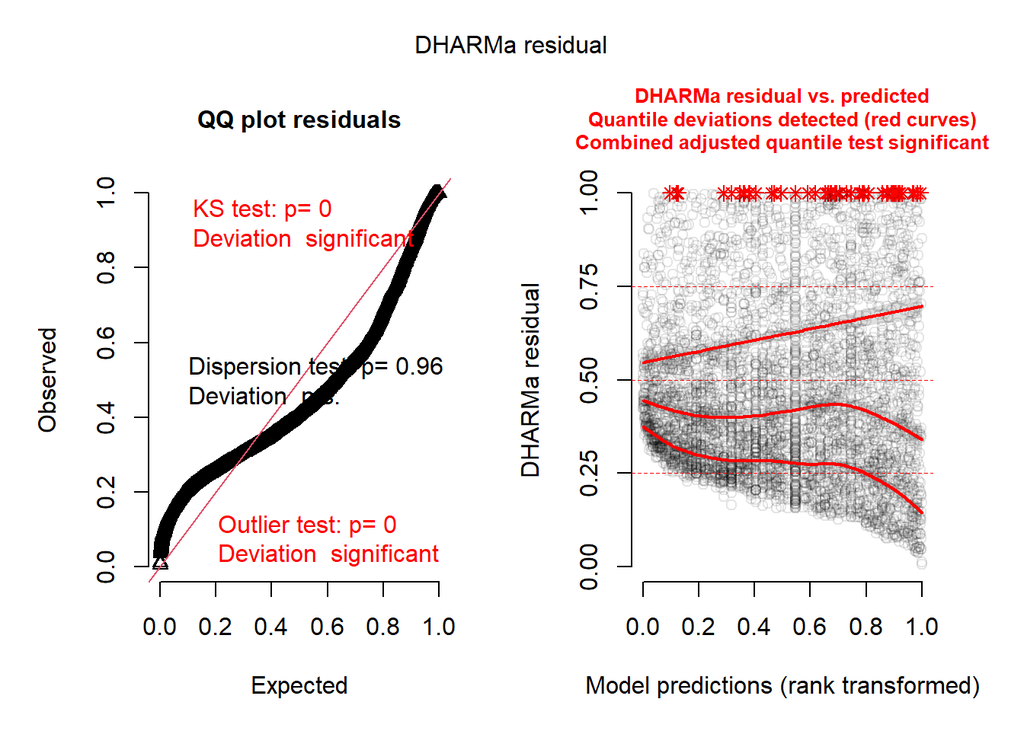

The Gaussian model assumes normally distributed errors and does not account for the discrete, non-negative nature of count outcomes. It can also generate negative predicted values, which are not meaningful for physician visits. Therefore, count regression models such as Poisson and negative binomial regression are more appropriate alternatives.

## 5. Fit nested Poisson models

### 5.1. Estimate three Poisson models

### 5.2. Compare the Poisson models

Likelihood Ratio Tests for Nested Poisson Models

| Model | Df | AIC | BIC | logLik | deviance | Chisq | Chi Df | Pr(>Chisq) |
| --- | --- | --- | --- | --- | --- | --- | --- | --- |
| M0 | 1.000 | 39,720.340 | 39,726.731 | −19,859.170 | 39,718.340 | NA | NA | NA |
| M1 | 2.000 | 37,546.913 | 37,559.694 | −18,771.456 | 37,542.913 | 2,175.428 | 1.000 | 0.000 |
| M2 | 7.000 | 36,596.989 | 36,641.724 | −18,291.494 | 36,582.989 | 959.924 | 5.000 | 0.000 |

The comparison between M0 and M1 evaluates whether chronic conditions improve model fit relative to the intercept-only model. The comparison between M1 and M2 evaluates whether adding health, gender, education, and insurance provides additional explanatory value.

The full Poisson model (M2) was retained for subsequent diagnostic assessment because it included all five predictors specified in the assignment.

## 6. Evaluate the Poisson model

### 6.1. Simulate residuals

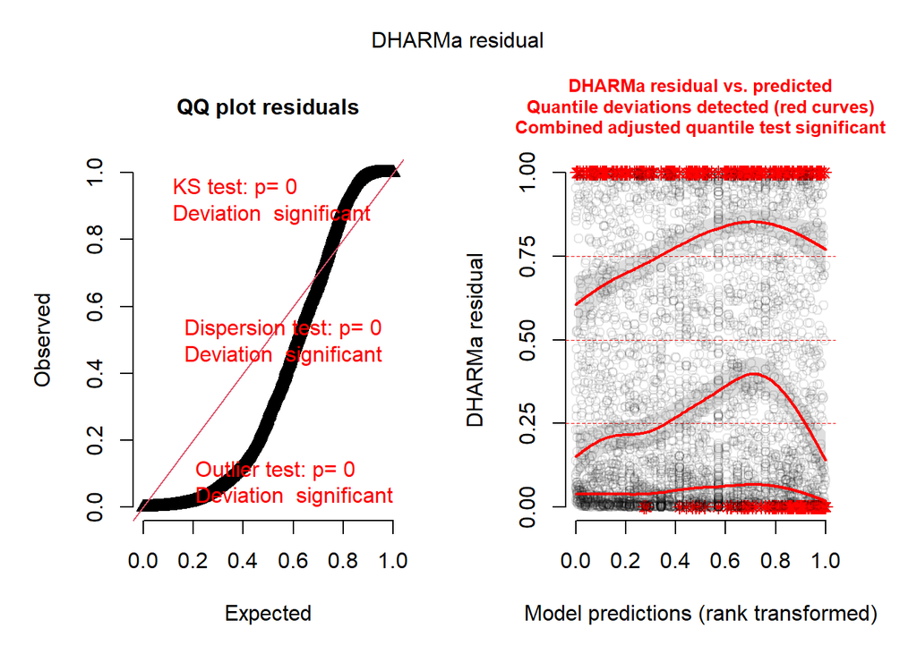

### 6.2. Test overdispersion and excess zeros

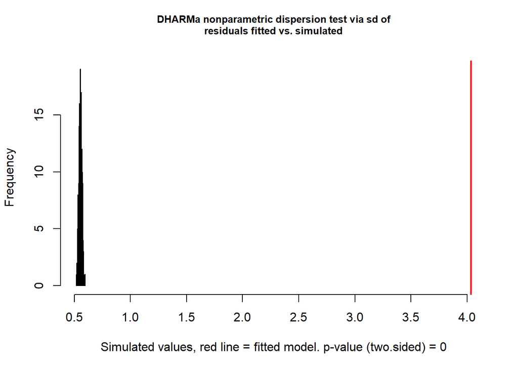

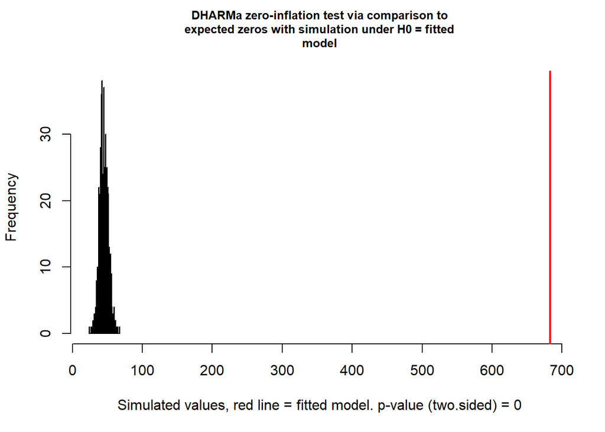

DHARMa Diagnostics for the Poisson Model

| Test | Statistic | P_value |
| --- | --- | --- |
| Dispersion | 7.252 | 0.000 |
| Zero inflation | 15.035 | 0.000 |

The DHARMa diagnostic plots and tests were used to evaluate the adequacy of the Poisson model. The dispersion test assesses whether the observed residual variability differs from that expected under the fitted model. The zero-inflation test compares the observed and expected number of zeros. Overdispersion matters because the Poisson model assumes equality between the conditional mean and variance. A significant zero-inflation test alone does not establish that a zero-inflated model is necessary, because excess zeros may also reflect overdispersion or unobserved heterogeneity.

## 7. Fit and evaluate a negative binomial model

### 7.1. Estimate the NB2 model

### 7.2. Compare Poisson and NB2 models

Poisson versus Negative Binomial Model

| Model | Df | AIC | BIC | logLik | deviance | Chisq | Chi Df | Pr(>Chisq) |
| --- | --- | --- | --- | --- | --- | --- | --- | --- |
| M2 | 7.000 | 36,596.989 | 36,641.724 | −18,291.494 | 36,582.989 | NA | NA | NA |
| neg_binom | 8.000 | 24,469.907 | 24,521.032 | −12,226.953 | 24,453.907 | 12,129.082 | 1.000 | 0.000 |

The likelihood ratio test compares the Poisson and NB2 models. The test has one degree of freedom because the NB2 model estimates an additional dispersion parameter.

### 7.3. DHARMa diagnostics for NB2

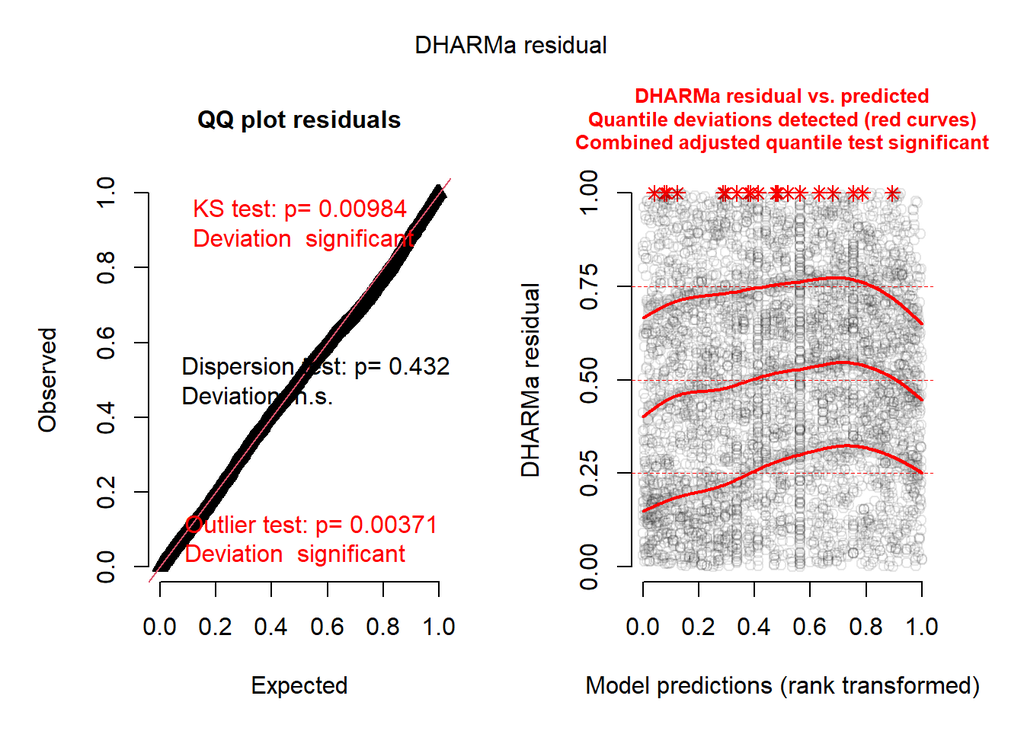

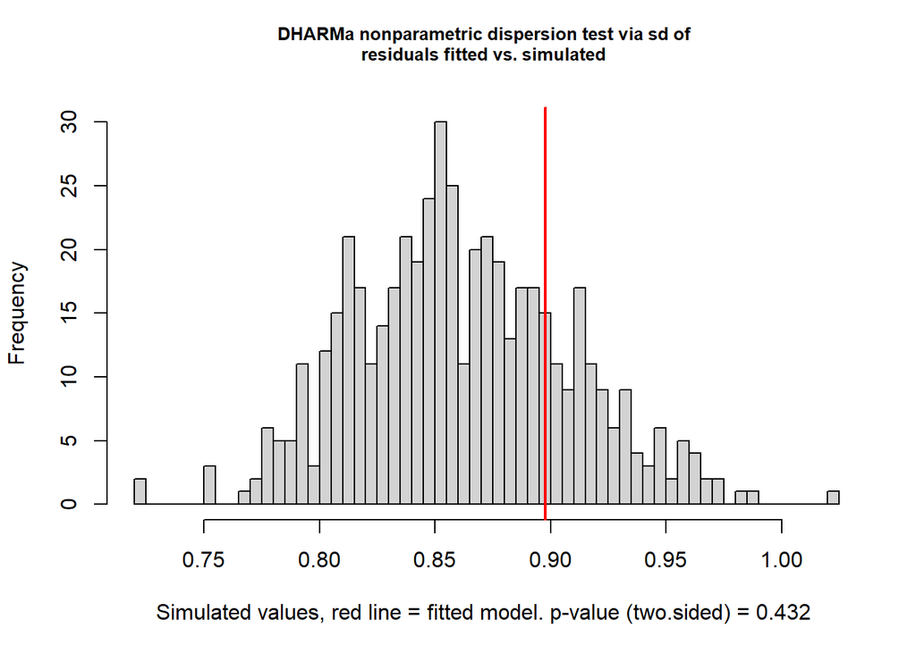

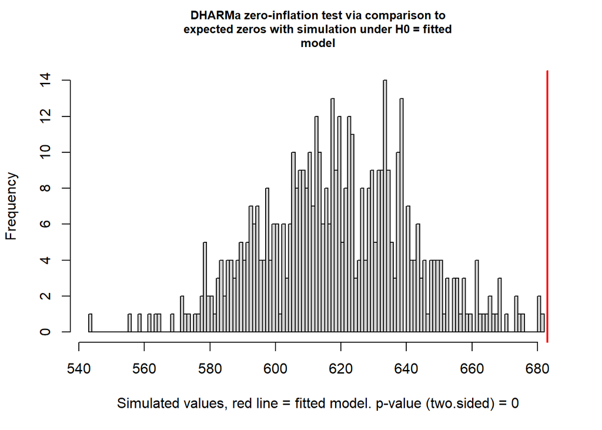

DHARMa Diagnostics for the NB2 Model

| Test | Statistic | P_value |
| --- | --- | --- |
| Dispersion | 1.042 | 0.432 |
| Zero inflation | 1.103 | 0.000 |

The NB2 model was evaluated using simulation-based residual diagnostics. The dispersion test assesses whether the negative binomial distribution adequately accounts for residual variability. The zero-inflation test assesses whether the model reproduces the observed number of zeros.

### 7.4. Visualize predicted counts

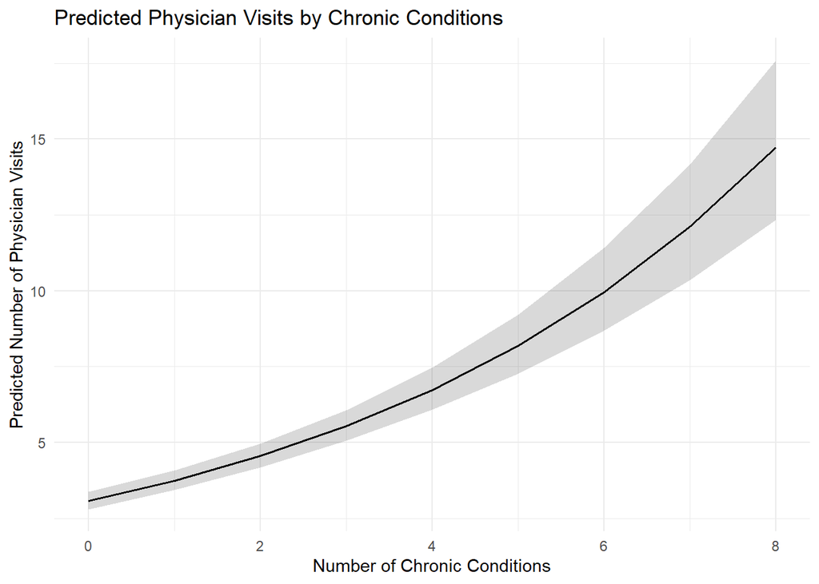

The predicted number of physician visits illustrates the association between chronic conditions and healthcare utilization. Because the model uses a logarithmic link function, the linear relationship is estimated on the log scale. When transformed back to the response scale, the predicted relationship may appear curved.

## 8. Zero-inflated and hurdle models

A large proportion of zero counts does not automatically indicate that a zero-inflated or hurdle model is necessary. The relevant question is whether the negative binomial model adequately reproduces the observed number of zeros.

### 8.1. Fit the ZINB model

The ZINB model includes a negative binomial count component and a separate zero-inflation component. The hurdle model estimates the probability of crossing the zero-count hurdle separately from the positive count distribution.

### 8.2. Compare NB2 and ZINB using an LRT

```
Data: data
Models:
neg_binom: visits ~ chronic + health + gender + school + insurance, zi=~0, disp=~1
m_zinb: visits ~ chronic + health + gender + school + insurance, zi=~chronic + health + gender + school + insurance, disp=~1
          Df   AIC   BIC logLik deviance  Chisq Chi Df Pr(>Chisq)
neg_binom  8 24470 24521 -12227    24454
m_zinb    15 24341 24437 -12155    24311 143.14      7  < 2.2e-16 ***
---
Signif. codes:  0 '***' 0.001 '**' 0.01 '*' 0.05 '.' 0.1 ' ' 1
```

The likelihood ratio test evaluates whether adding a zero-inflation component improves the fit relative to the NB2 model. Because the null hypothesis places zero-inflation parameters on the boundary of the parameter space, the usual chi-square reference distribution should be interpreted with some caution.

### 8.3. Compare NB2, ZINB, and hurdle models

Comparison of NB2, ZINB, and Hurdle Models

| Model | AIC | BIC |
| --- | --- | --- |
| NB2 | 24,469.91 | 24,521.03 |
| ZINB | 24,340.77 | 24,436.63 |
| Hurdle NB2 | 24,330.41 | 24,426.27 |

The NB2 and ZINB models are nested and can be compared using a likelihood ratio test. The hurdle model is not nested in the NB2 model; therefore, AIC and BIC are used to compare their relative fit and complexity.

### 8.4. DHARMa diagnostics for ZINB and hurdle models

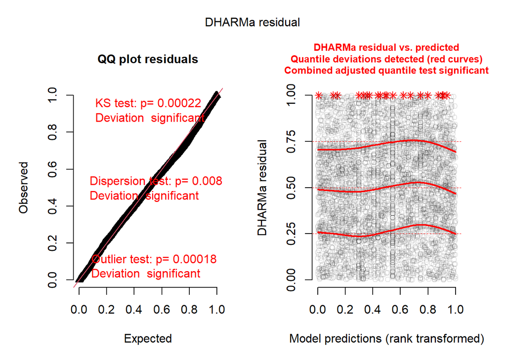

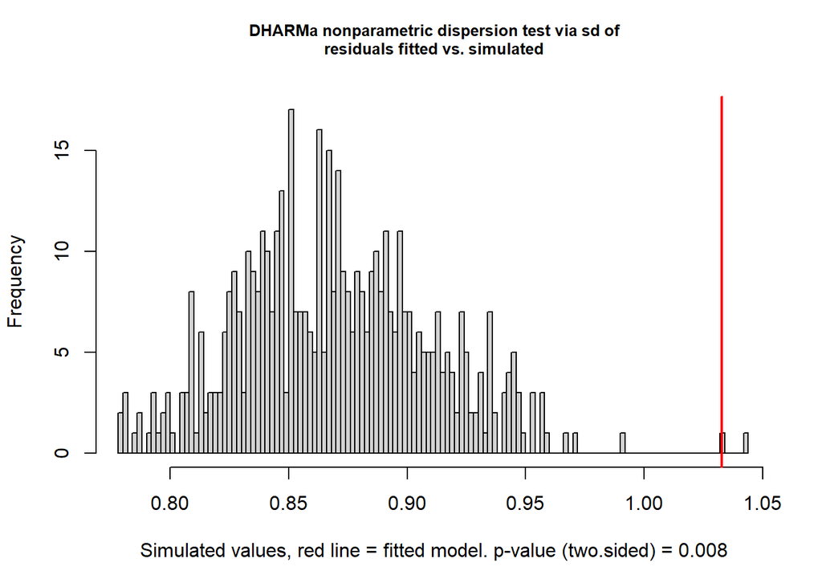

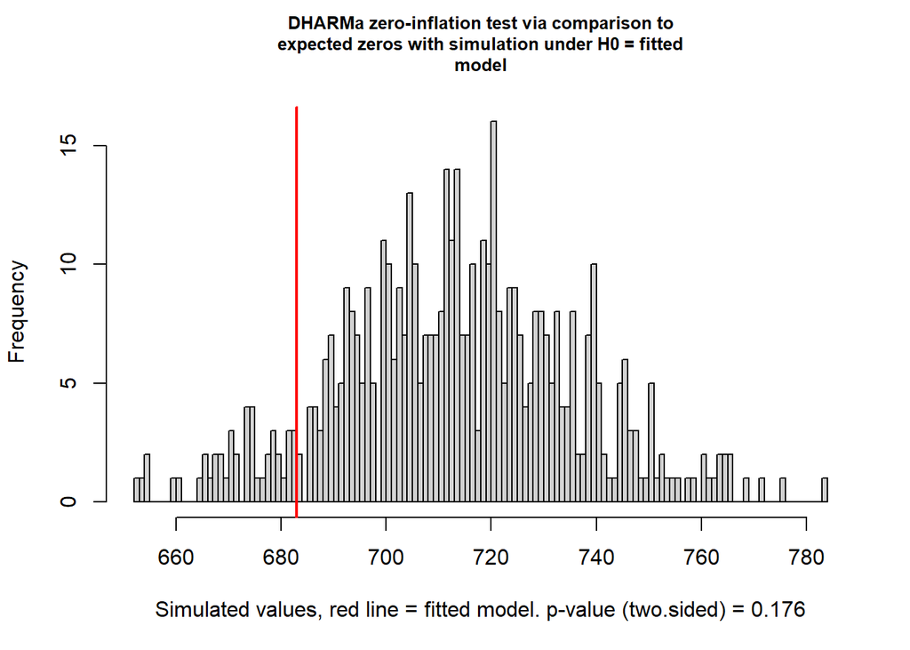

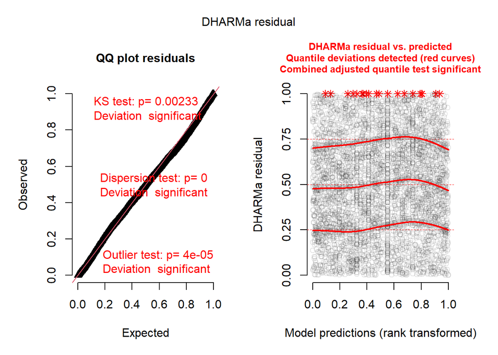

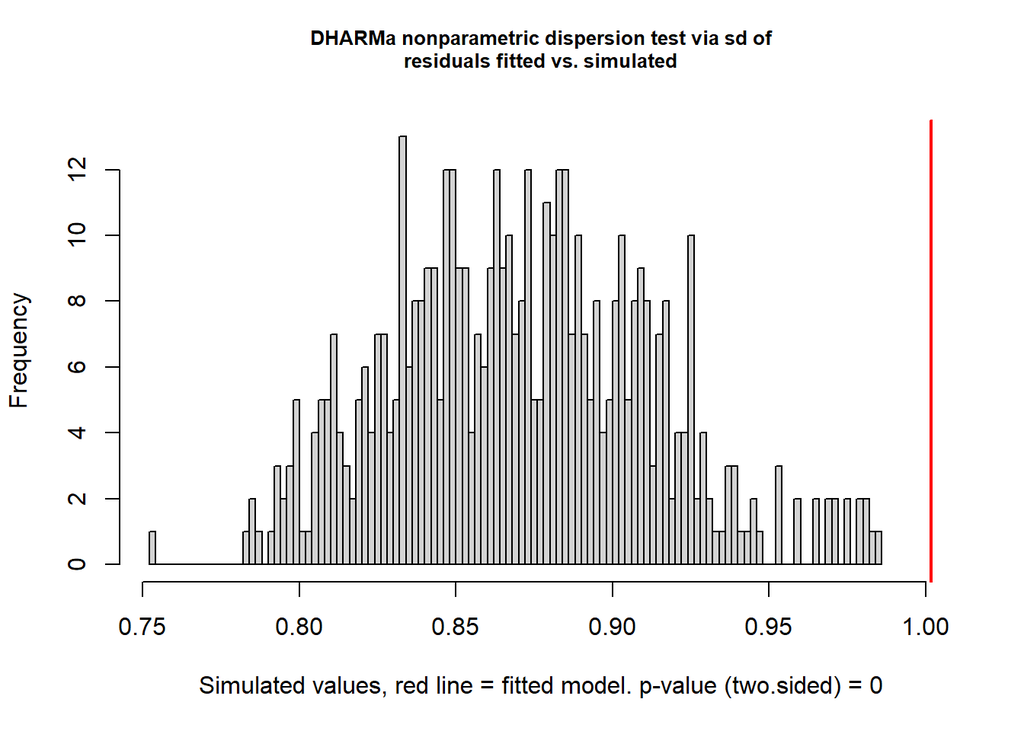

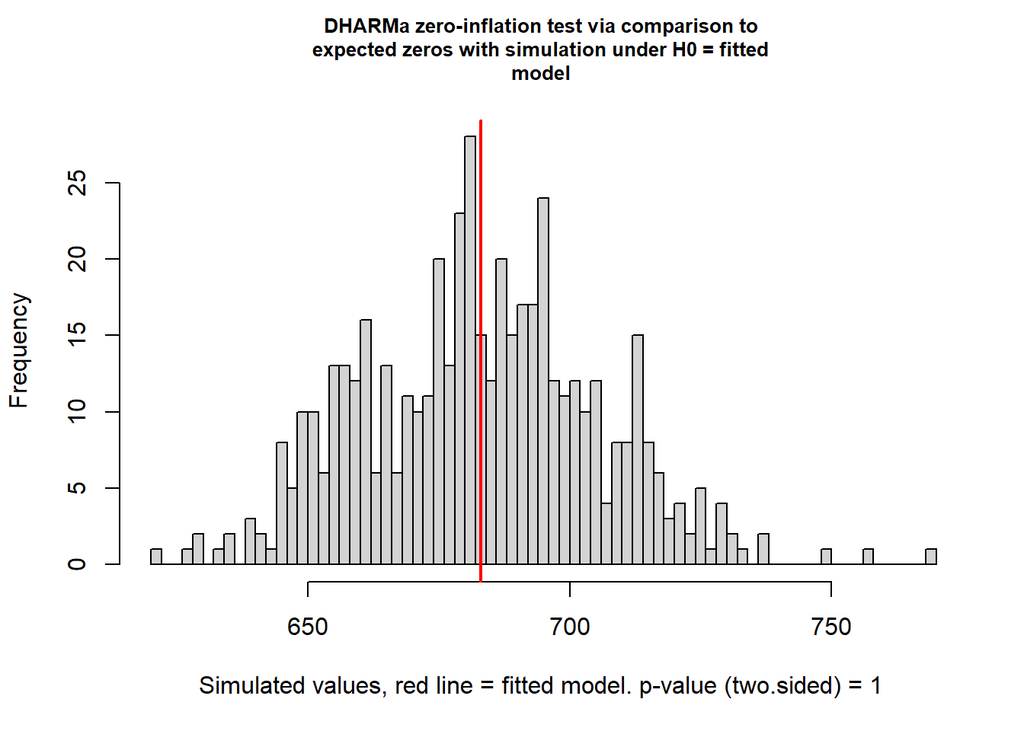

The DHARMa residual simulations were used to assess whether the ZINB and hurdle models adequately reproduced the dispersion and zero-count patterns in the data.

### 8.5. Select the model to carry forward

### 8.6. Re-check the selected model with DHARMa

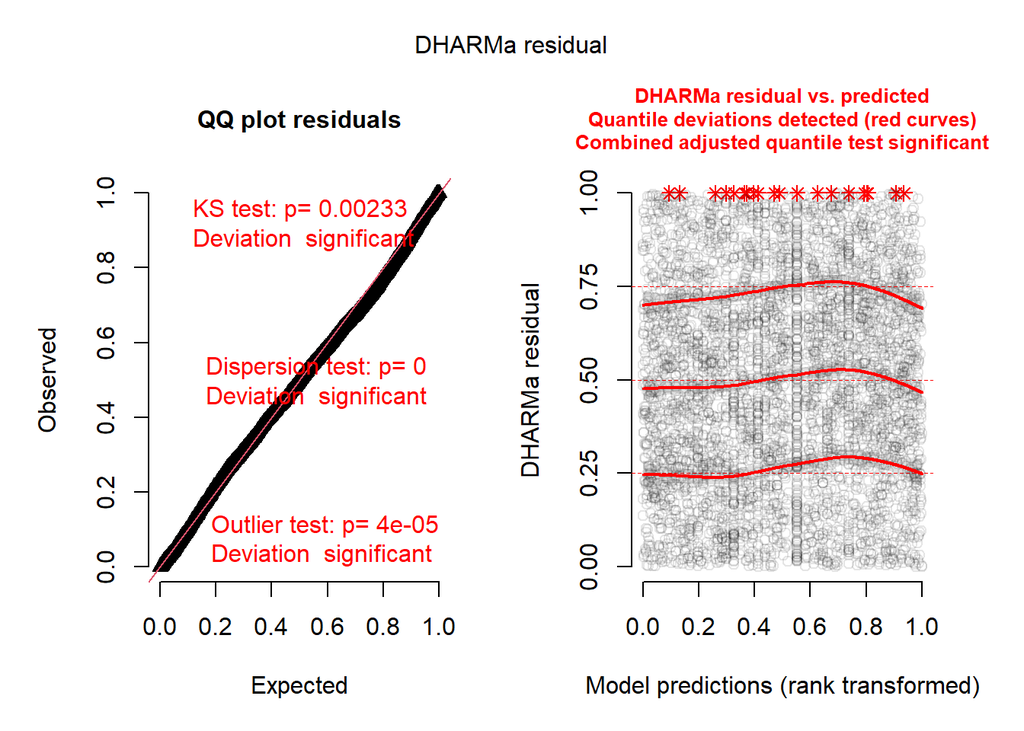

```r
# Re-check the selected model with DHARMa

if (selected_model_type == "NB2") {
  res_selected <- res_nb
} else if (selected_model_type == "ZINB") {
  res_selected <- res_zinb
} else {
  res_selected <- res_hurd
}

plot(res_selected)
```

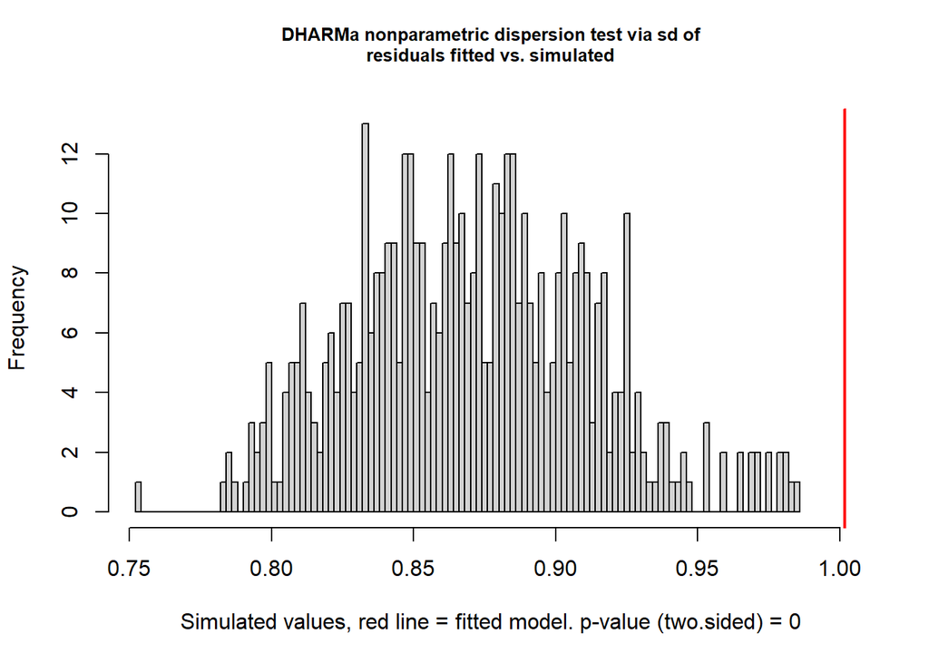

```r
selected_disp <- DHARMa::testDispersion(res_selected)
```

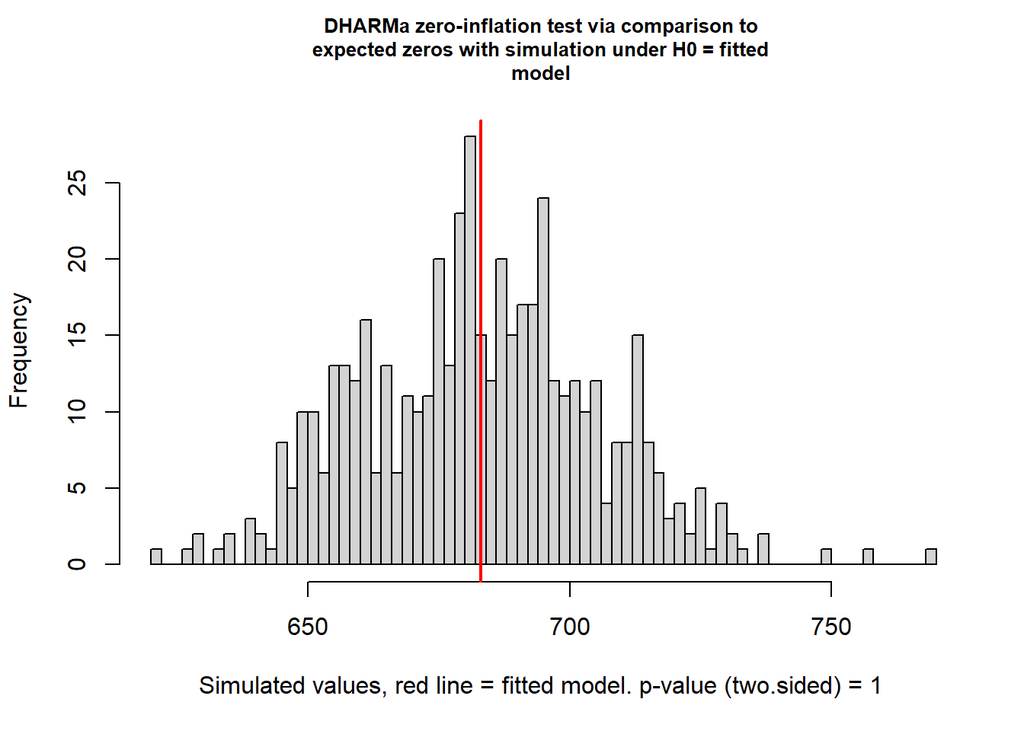

```r
selected_zi <- DHARMa::testZeroInflation(res_selected)
```

```r
selected_diagnostics <- tibble(
  Test = c("Dispersion", "Zero inflation"),
  Statistic = c(
    unname(selected_disp$statistic),
    unname(selected_zi$statistic)
  ),
  P_value = c(
    selected_disp$p.value,
    selected_zi$p.value
  )
)

selected_diagnostics
```

```
# A tibble: 2 × 3
  Test           Statistic P_value
  <chr>              <dbl>   <dbl>
1 Dispersion         1.15        0
2 Zero inflation     0.999       1
```

The model selected for further analysis was Hurdle NB2. The selection considered the NB2 zero-inflation test and the AIC values of the candidate models. The DHARMa diagnostics of the selected model were also examined to assess whether important dispersion or zero-inflation problems remained.

## 9. Test an interaction between chronic conditions and insurance

The interaction analysis examines whether the association between chronic conditions and physician visits differs according to private insurance status.

### 9.1. State the prediction

I expected the association between chronic conditions and physician visits to be positive in both insurance groups because individuals with more chronic conditions may require more medical care. I also expected this association to differ between insured and uninsured individuals, potentially being stronger among those with private insurance because insurance may reduce financial barriers to healthcare access.

### 9.2. Fit the additive and interaction models

### 9.3. Test whether the interaction improves fit

```
Data: data
Models:
additive_model: visits ~ chronic + health + gender + school + insurance, zi=~chronic + health + gender + school + insurance, disp=~1
interact: visits ~ chronic * insurance + health + gender + school, zi=~chronic + health + gender + school + insurance, disp=~1
               Df   AIC   BIC logLik deviance Chisq Chi Df Pr(>Chisq)
additive_model 15 24330 24426 -12150    24300
interact       16 24332 24434 -12150    24300 0.341      1     0.5593
```

The likelihood ratio test evaluates whether including the interaction between chronic conditions and insurance improves model fit compared with the additive model. The interaction is statistically significant if its p-value is below .05.

### 9.4. Plot predicted counts

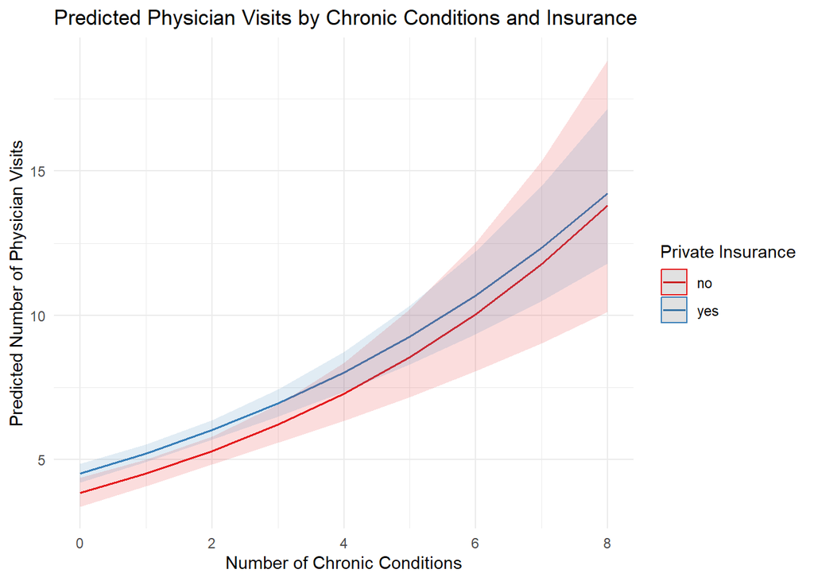

The predicted values illustrate how physician visits change with chronic conditions for individuals with and without private insurance. Differences in the slopes indicate how the association between chronic conditions and visits may vary by insurance status.

### 9.5. Estimate simple slopes

Simple Slopes of Chronic Conditions by Insurance Status

| insurance | chronic.trend | SE | df | asymp.LCL | asymp.UCL | z.ratio | p.value |
| --- | --- | --- | --- | --- | --- | --- | --- |
| no | 0.160 | 0.025 | Inf | 0.111 | 0.208 | 6.462 | 0.000 |
| yes | 0.143 | 0.014 | Inf | 0.115 | 0.172 | 9.945 | 0.000 |

The simple-slopes analysis estimates the association between chronic conditions and physician visits separately for individuals with and without private insurance. The slopes are expressed on the log scale because the negative binomial model uses a logarithmic link function.

### 9.6. Compare the two simple slopes

Comparison of Chronic-Condition Slopes

| contrast | estimate | SE | df | asymp.LCL | asymp.UCL | z.ratio | p.value |
| --- | --- | --- | --- | --- | --- | --- | --- |
| no - yes | 0.016 | 0.028 | Inf | −0.039 | 0.072 | 0.583 | 0.560 |

The comparison obtained using `pairs()` tests whether the two chronic-condition slopes differ. Its estimate represents the difference between the slopes, while its standard error and p-value quantify the uncertainty and statistical evidence for that difference. The direction of the estimate depends on the order of subtraction.

### 9.7. Calculate low, average, and high chronic-condition values

### 9.8. Estimate simple effects of insurance

```
chronic = 0.192:
 insurance emmean     SE  df asymp.LCL asymp.UCL
 no          1.40 0.0616 Inf      1.27      1.52
 yes         1.55 0.0364 Inf      1.48      1.62

chronic = 1.542:
 insurance emmean     SE  df asymp.LCL asymp.UCL
 no          1.61 0.0450 Inf      1.52      1.70
 yes         1.75 0.0291 Inf      1.69      1.80

chronic = 2.892:
 insurance emmean     SE  df asymp.LCL asymp.UCL
 no          1.83 0.0498 Inf      1.73      1.92
 yes         1.94 0.0336 Inf      1.87      2.01

Results are averaged over the levels of: health, gender
Results are given on the log (not the response) scale.
Confidence level used: 0.95
```

The estimated marginal means compare insurance groups at low, average, and high levels of chronic conditions.

### 9.9. Compare insurance groups at each chronic-condition level

```
chronic = 0.1923565:
 contrast   estimate         SE  df  asymp.LCL   asymp.UCL z.ratio p.value
 no - yes -0.1584607 0.06467852 Inf -0.2852282 -0.03169309  -2.450  0.0143

chronic = 1.5419882:
 contrast   estimate         SE  df  asymp.LCL   asymp.UCL z.ratio p.value
 no - yes -0.1362683 0.04460000 Inf -0.2236827 -0.04885393  -3.055  0.0022

chronic = 2.8916199:
 contrast   estimate         SE  df  asymp.LCL   asymp.UCL z.ratio p.value
 no - yes -0.1140760 0.05186743 Inf -0.2157343 -0.01241769  -2.199  0.0279

Results are averaged over the levels of: health, gender
Results are given on the log (not the response) scale.
Confidence level used: 0.95
```

### 9.10. Present the interaction contrasts

Simple Effects of Insurance

Comparisons at Low, Average, and High Chronic Conditions

| Chronic Conditions | Contrast | Log Contrast | SE | z | p |
| --- | --- | --- | --- | --- | --- |
| -1 SD | no - yes | −0.158 | 0.065 | −2.450 | 0.014 |
| Mean | no - yes | −0.136 | 0.045 | −3.055 | 0.002 |
| +1 SD | no - yes | −0.114 | 0.052 | −2.199 | 0.028 |

### 9.11. Interpret the interaction

The interaction should be interpreted by considering the omnibus likelihood ratio test, the estimated simple slopes, and the simple effects of insurance at different levels of chronic conditions. The omnibus test evaluates whether the slopes differ overall, whereas the probing analyses describe the direction and magnitude of the differences and identify the chronic-condition values at which insurance groups differ.

## 10. Regression coefficients for the selected model

Regression Results: Hurdle NB2

| Predictor | Coefficient | 95% CI Lower | 95% CI Upper | p |
| --- | --- | --- | --- | --- |
| (Intercept) | 1.138 | 1.012 | 1.264 | 0.000 |
| chronic | 0.148 | 0.123 | 0.172 | 0.000 |
| healthpoor | 0.383 | 0.287 | 0.478 | 0.000 |
| healthexcellent | −0.368 | −0.501 | −0.236 | 0.000 |
| genderfemale | 0.056 | −0.008 | 0.121 | 0.088 |
| school | 0.021 | 0.012 | 0.030 | 0.000 |
| insuranceyes | 0.130 | 0.045 | 0.216 | 0.003 |

The regression coefficients represent changes in the logarithm of the expected number of physician visits for the count component of the selected model. Positive coefficients indicate higher expected visit counts, whereas negative coefficients indicate lower expected visit counts, relative to the relevant reference categories and holding the other predictors constant.

## 11. APA-style results

### 11.1. Model selection

The sample included 4406 individuals. The mean number of physician visits was 5.77, the variance was 45.69, and 15.5% of individuals reported zero visits.

The Poisson model showed a dispersion statistic of 7.252 (p = <2e-16) and a zero-inflation statistic of 15.035 (p = <2e-16).

The model carried forward was Hurdle NB2.

### 11.2. Main effects

The selected model estimated the associations between chronic conditions, health, gender, education, and private insurance and physician visits, holding the other predictors constant. The regression coefficients, 95% confidence intervals, and p-values are presented in the coefficient table above.

Positive coefficients indicate higher expected visit counts, whereas negative coefficients indicate lower expected visit counts relative to the reference category or for a one-unit increase in a continuous predictor.

### 11.3. Interaction

The likelihood ratio test comparing the additive and interaction models yielded χ²(1) = 0.341, p = 0.559.

The estimated chronic-condition slope was 0.16 (95% CI [0.111, 0.208], p = 1.03e-10) for the no insurance group and 0.143 (95% CI [0.115, 0.172], p = <2e-16) for the yes insurance group.

The simple-effects analysis compared insurance groups at low, average, and high levels of chronic conditions. The corresponding log contrasts were -0.158, -0.136, and -0.114, with p-values of 0.0143, 0.00225, and 0.0279, respectively.

Together, these results indicate whether the association between chronic conditions and physician visits varies according to insurance status.

## 12. Discussion

The analysis examined the factors associated with physician office visits among older adults. Chronic conditions are expected to be an important predictor of healthcare utilization because individuals with more chronic illnesses may require more frequent medical care. Self-perceived health may also contribute to differences in healthcare use, while gender, education, and private insurance may provide additional information about variation in physician visits.

The comparison of Poisson and negative binomial models demonstrates the importance of accounting for overdispersion in count data. The zero-inflation and hurdle analyses further assess whether a separate process is needed to explain individuals with no physician visits. The interaction analysis evaluates whether the association between chronic conditions and physician visits differs by insurance status.

Several limitations should be considered. The data are observational and therefore do not establish causal relationships. The analysis is based on a historical US survey, so the findings may not generalize to current healthcare systems or other populations. In addition, unmeasured factors such as income, access to healthcare, disease severity, and individual healthcare-seeking behaviour may influence physician visits.

## 13. Conclusion

This analysis used count regression models to investigate physician office visits among older adults. Poisson and negative binomial models were compared using likelihood ratio tests and simulation-based residual diagnostics. Zero-inflated and hurdle models were also evaluated to determine whether the observed zeros required a separate modelling process. Finally, the interaction between chronic conditions and private insurance was examined using predicted counts, simple slopes, and simple effects.

The final model selection and substantive conclusions were based on model fit, diagnostic evidence, and the interaction analyses.